# report

Pavel Vychyk

10/04/2022

#### Check for required packages

```r
pckages <- c('xlsx', 'ggplot2', 'ggpubr', 'car', 'FSA', 'ggfortify', 'knitr')
for(package in pckages) {
  if(!require(package, character.only = T)) {
    install.packages(package, dependencies = T)
    library(package)
  }
}
```

#### Load required libraries

```r
library(xlsx)
library(ggplot2)
library(ggpubr)
library(car)
library(FSA)
library(ggfortify)
library(knitr)
```

#### provide the path to the data file and read

```r
data_mice <- read.xlsx("data/Data_Cortex_Nuclear.xls", "Hoja1")
```

#### 1. EDA

Lets look on the data. We could see, that column MouseID has repeats for the same object

```r
head(data_mice)
```

```
##   MouseID  DYRK1A_N   ITSN1_N    BDNF_N    NR1_N   NR2A_N    pAKT_N   pBRAF_N
## 1   309_1 0.5036439 0.7471932 0.4301753 2.816329 5.990152 0.2188300 0.1775655
## 2   309_2 0.5146171 0.6890635 0.4117703 2.789514 5.685038 0.2116362 0.1728170
## 3   309_3 0.5091831 0.7302468 0.4183088 2.687201 5.622059 0.2090109 0.1757222
## 4   309_4 0.4421067 0.6170762 0.3586263 2.466947 4.979503 0.2228858 0.1764626
## 5   309_5 0.4349402 0.6174298 0.3588022 2.365785 4.718679 0.2131059 0.1736270
## 6   309_6 0.4475064 0.6281758 0.3673881 2.385939 4.807635 0.2185778 0.1762334
##   pCAMKII_N   pCREB_N   pELK_N    pERK_N    pJNK_N    PKCA_N    pMEK_N
## 1  2.373744 0.2322238 1.750936 0.6879062 0.3063817 0.4026984 0.2969273
## 2  2.292150 0.2269721 1.596377 0.6950062 0.2990511 0.3859868 0.2813189
## 3  2.283337 0.2302468 1.561316 0.6773484 0.2912761 0.3810025 0.2817103
## 4  2.152301 0.2070042 1.595086 0.5832768 0.2967287 0.3770870 0.3138320
## 5  2.134014 0.1921579 1.504230 0.5509601 0.2869612 0.3635021 0.2779643
## 6  2.141282 0.1951875 1.442398 0.5663396 0.2898239 0.3638930 0.2668369
##      pNR1_N   pNR2A_N  pNR2B_N pPKCAB_N    pRSK_N     AKT_N    BRAF_N  CAMKII_N
```

[output cut: 69 more lines]

Get the number of mice in the data set

```r
length(unique(sapply(strsplit(data_mice$MouseID, "_"), "[", 1)))
```

```
## [1] 72
```

Look on the presented groups

```r
unique(data_mice$class)
```

```
## [1] "c-CS-m" "c-SC-m" "c-CS-s" "c-SC-s" "t-CS-m" "t-SC-m" "t-CS-s" "t-SC-s"
```

```r
unique(data_mice$Treatment)
```

```
## [1] "Memantine" "Saline"
```

```r
unique(data_mice$Genotype)
```

```
## [1] "Control" "Ts65Dn"
```

```r
unique(data_mice$Behavior)
```

```
## [1] "C/S" "S/C"
```

Check the groups balance

```r
table(data_mice$class)
```

```
##
## c-CS-m c-CS-s c-SC-m c-SC-s t-CS-m t-CS-s t-SC-m t-SC-s
##    150    135    150    135    135    105    135    135
```

```r
table(data_mice$Treatment)
```

```
##
## Memantine    Saline
##       570       510
```

```r
table(data_mice$Genotype)
```

```
##
## Control  Ts65Dn
##     570     510
```

```r
table(data_mice$Behavior)
```

```
##
## C/S S/C
## 525 555
```

Count NA in samples

```r
sapply(data_mice, function(y) sum(is.na(data_mice)))
```

```
##         MouseID        DYRK1A_N         ITSN1_N          BDNF_N           NR1_N
##            1396            1396            1396            1396            1396
##          NR2A_N          pAKT_N         pBRAF_N       pCAMKII_N         pCREB_N
##            1396            1396            1396            1396            1396
##          pELK_N          pERK_N          pJNK_N          PKCA_N          pMEK_N
##            1396            1396            1396            1396            1396
##          pNR1_N         pNR2A_N         pNR2B_N        pPKCAB_N          pRSK_N
##            1396            1396            1396            1396            1396
##           AKT_N          BRAF_N        CAMKII_N          CREB_N           ELK_N
##            1396            1396            1396            1396            1396
##           ERK_N         GSK3B_N           JNK_N           MEK_N          TRKA_N
##            1396            1396            1396            1396            1396
##           RSK_N           APP_N      Bcatenin_N          SOD1_N          MTOR_N
##            1396            1396            1396            1396            1396
##           P38_N         pMTOR_N         DSCR1_N         AMPKA_N          NR2B_N
##            1396            1396            1396            1396            1396
##         pNUMB_N        RAPTOR_N         TIAM1_N        pP70S6_N          NUMB_N
##            1396            1396            1396            1396            1396
##         P70S6_N        pGSK3B_N         pPKCG_N          CDK5_N            S6_N
##            1396            1396            1396            1396            1396
##        ADARB1_N    AcetylH3K9_N          RRP1_N           BAX_N           ARC_N
##            1396            1396            1396            1396            1396
##         ERBB4_N          nNOS_N           Tau_N          GFAP_N         GluR3_N
##            1396            1396            1396            1396            1396
##         GluR4_N          IL1B_N         P3525_N        pCASP9_N         PSD95_N
##            1396            1396            1396            1396            1396
##          SNCA_N     Ubiquitin_N pGSK3B_Tyr216_N           SHH_N           BAD_N
##            1396            1396            1396            1396            1396
##          BCL2_N           pS6_N         pCFOS_N           SYP_N       H3AcK18_N
##            1396            1396            1396            1396            1396
##          EGR1_N        H3MeK4_N          CaNA_N        Genotype       Treatment
##            1396            1396            1396            1396            1396
##        Behavior           class
##            1396            1396
```

```r
nrow(data_mice[rowSums(is.na(data_mice))>0, ])
```

```
## [1] 528
```

#### 2. Is there any difference in BDNF_N expression levels regarding to the class

Let’s drop incomplete cases

```r
complete_data <- data_mice[complete.cases(data_mice),]
```

And look on the assumptions for comparison tests, firstly check normality distribution using graphical analysis and Shapiro–Wilk test QQ-plot:

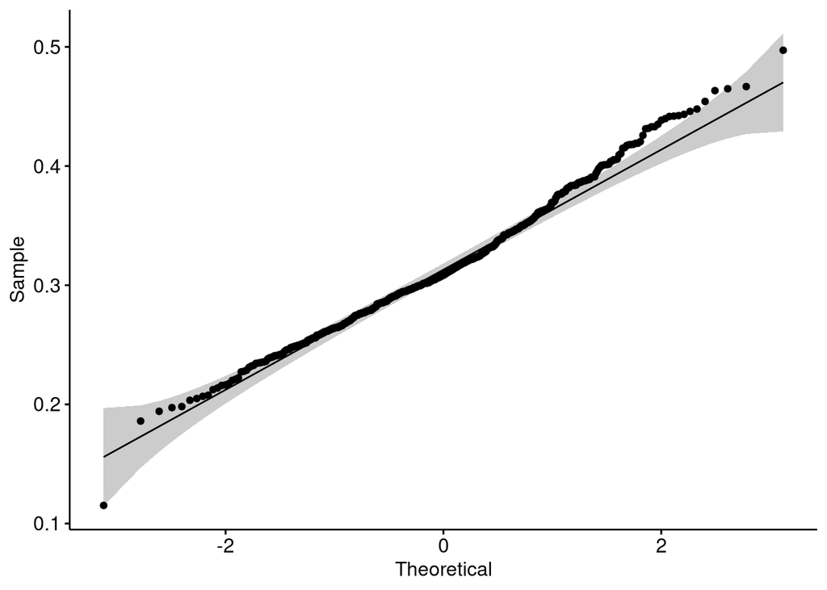

```r
ggqqplot(complete_data$BDNF_N)
```

Shapiro-Wilk test result:

```r
shtest <- shapiro.test(complete_data$BDNF_N)
shapiro.test(complete_data$BDNF_N)
```

```
##
##  Shapiro-Wilk normality test
##
## data:  complete_data$BDNF_N
## W = 0.98792, p-value = 0.0001591
```

Check homogeneity of variances assumption within classes

```r
complete_data$class <- as.factor(complete_data$class)
lvtest <- leveneTest(BDNF_N ~ class, data=complete_data)
leveneTest(BDNF_N ~ class, data=complete_data)
```

```
## Levene's Test for Homogeneity of Variance (center = median)
##        Df F value    Pr(>F)
## group   7  7.3839 1.729e-08 ***
##       544
## ---
## Signif. codes:  0 '***' 0.001 '**' 0.01 '*' 0.05 '.' 0.1 ' ' 1
```

```r
kwtest <- kruskal.test(BDNF_N ~ class, data=complete_data)
kruskal.test(BDNF_N ~ class, data=complete_data)
```

```
##
##  Kruskal-Wallis rank sum test
##
## data:  BDNF_N by class
## Kruskal-Wallis chi-squared = 46.072, df = 7, p-value = 8.466e-08
```

Kruskal-Wallis test **rejects the null hypothesis** for equality of medians within groups **(p-value = 8.466059^{-8})**. We should perform post-hoc analysis to find which groups have significant difference in medians. For post-hoc we use Dunn’s test:

```r
dTest <- dunnTest(BDNF_N ~ class, data=complete_data, method = "bh")
dResult <- dTest$res
dResult[dResult$P.adj < 0.05, ]
```

```
##         Comparison         Z      P.unadj        P.adj
## 2  c-CS-m - c-SC-m  4.503626 6.680369e-06 3.741007e-05
## 3  c-CS-s - c-SC-m  5.210621 1.882101e-07 1.756627e-06
## 6  c-SC-m - c-SC-s -4.845734 1.261447e-06 8.830132e-06
## 9  c-SC-m - t-CS-m -5.669425 1.432774e-08 4.011766e-07
## 13 c-SC-m - t-CS-s -3.507814 4.518041e-04 1.807216e-03
## 18 c-SC-m - t-SC-m -3.995632 6.452177e-05 3.011016e-04
## 24 c-SC-m - t-SC-s -5.666429 1.458045e-08 2.041263e-07
```

Dunn test shows statistical significant difference in medians for classes at p-value level < 0.05, most significant difference was for classes below: c-SC-m: control mice, not stimulated to learn, injected with memantine t-SC-s: trisomy mice, not stimulated to learn, injected with saline Let’s visualize BDNF_N expressions difference for classes with boxplot graphs:

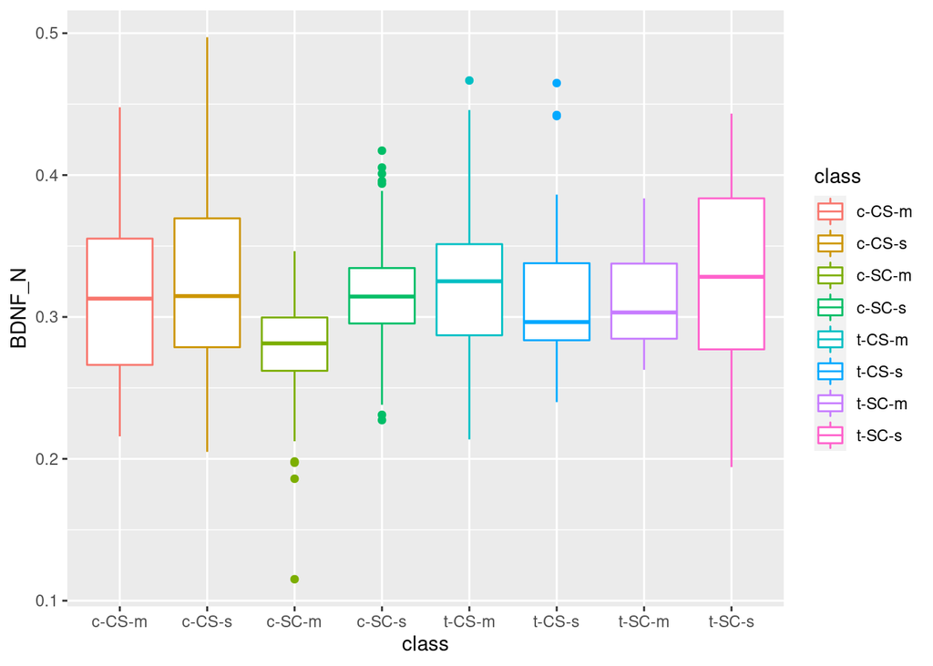

```r
ggplot(complete_data, aes(x = class, y = BDNF_N, col = class)) + geom_boxplot()
```

#### 3. Try to predict BDNF_N expression based on other proteins expression levels with linear model Build linear model using as predictor variables all columns, except categorical data

```r
f_model <- lm(BDNF_N ~ . - MouseID - Genotype - Treatment - Behavior - class, data = complete_data)
summary(f_model)
```

```
##
## Call:
## lm(formula = BDNF_N ~ . - MouseID - Genotype - Treatment - Behavior -
##     class, data = complete_data)
##
## Residuals:
##       Min        1Q    Median        3Q       Max
## -0.125305 -0.006585 -0.000166  0.006715  0.094184
##
## Coefficients: (1 not defined because of singularities)
##                   Estimate Std. Error t value Pr(>|t|)
## (Intercept)     -0.0391525  0.0197252  -1.985 0.047730 *
## DYRK1A_N         0.0225581  0.0177621   1.270 0.204700
## ITSN1_N         -0.0470665  0.0250860  -1.876 0.061238 .
## NR1_N            0.0151931  0.0159570   0.952 0.341516
## NR2A_N           0.0019583  0.0032357   0.605 0.545314
## pAKT_N           0.0129974  0.0729184   0.178 0.858606
## pBRAF_N          0.0141157  0.0730326   0.193 0.846823
## pCAMKII_N        0.0029211  0.0018868   1.548 0.122242
## pCREB_N          0.0073625  0.0695203   0.106 0.915702
## pELK_N           0.0004772  0.0024498   0.195 0.845642
## pERK_N           0.0413204  0.0187875   2.199 0.028332 *
## pJNK_N          -0.1726936  0.0602008  -2.869 0.004306 **
## PKCA_N           0.0826242  0.0649701   1.272 0.204092
## pMEK_N           0.0853532  0.0642540   1.328 0.184692
## pNR1_N           0.0377055  0.0317949   1.186 0.236254
## pNR2A_N         -0.0171149  0.0172326  -0.993 0.321133
## pNR2B_N         -0.0197785  0.0159496  -1.240 0.215563
## pPKCAB_N        -0.0006045  0.0066243  -0.091 0.927333
## pRSK_N          -0.0083247  0.0339569  -0.245 0.806442
## AKT_N           -0.0343740  0.0193975  -1.772 0.077020 .
## BRAF_N          -0.0283759  0.0288741  -0.983 0.326232
## CAMKII_N        -0.0054675  0.0478332  -0.114 0.909045
## CREB_N          -0.0029010  0.0735316  -0.039 0.968546
## ELK_N            0.0270781  0.0087664   3.089 0.002127 **
## ERK_N            0.0203596  0.0066232   3.074 0.002234 **
## GSK3B_N          0.0197594  0.0162168   1.218 0.223655
## JNK_N            0.0562033  0.0803068   0.700 0.484358
## MEK_N            0.0492351  0.0522217   0.943 0.346257
## TRKA_N           0.0801507  0.0389789   2.056 0.040303 *
```

[output cut: 39 more lines]

```
## BAD_N            0.1998814  0.0830120   2.408 0.016426 *
## BCL2_N           0.0695223  0.0739469   0.940 0.347610
## pS6_N                   NA         NA      NA       NA
## pCFOS_N         -0.0026862  0.0740016  -0.036 0.971059
## SYP_N            0.0244058  0.0256871   0.950 0.342534
## H3AcK18_N       -0.0212252  0.0600877  -0.353 0.724067
## EGR1_N           0.0806787  0.0621761   1.298 0.195059
## H3MeK4_N        -0.1123225  0.0509829  -2.203 0.028063 *
## CaNA_N          -0.0101674  0.0081193  -1.252 0.211096
## ---
## Signif. codes:  0 '***' 0.001 '**' 0.01 '*' 0.05 '.' 0.1 ' ' 1
##
## Residual standard error: 0.01399 on 476 degrees of freedom
## Multiple R-squared:  0.9405, Adjusted R-squared:  0.9311
## F-statistic: 100.3 on 75 and 476 DF,  p-value: < 2.2e-16
```

R-square seems significant, but is our model really good? Residuals vs Fitted shows good support for the linear assumptions

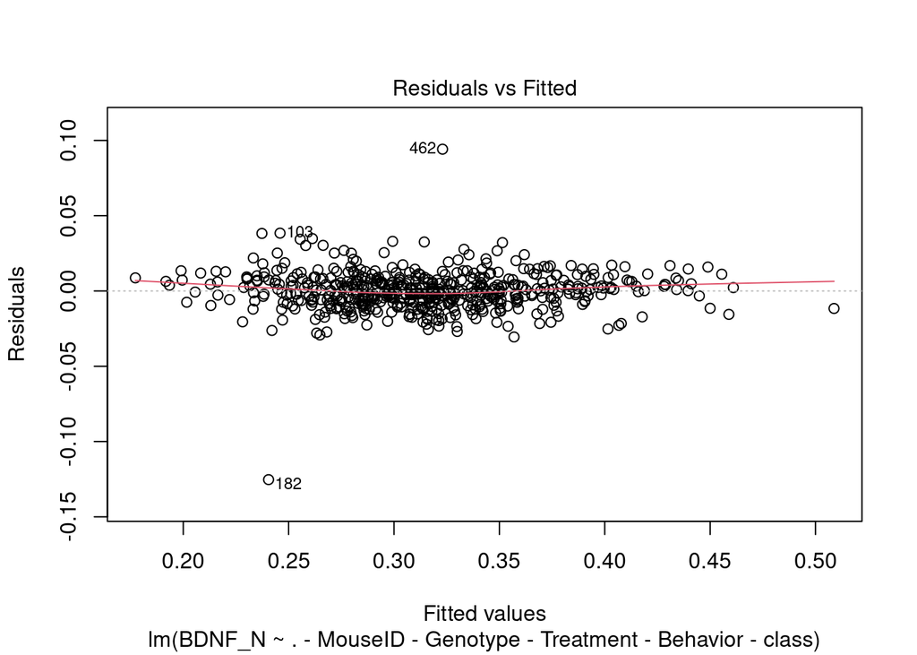

```r
plot(f_model, 1)
```

Normal QQ shows the presence of several outliers, but in general model’s residual are normally distributed

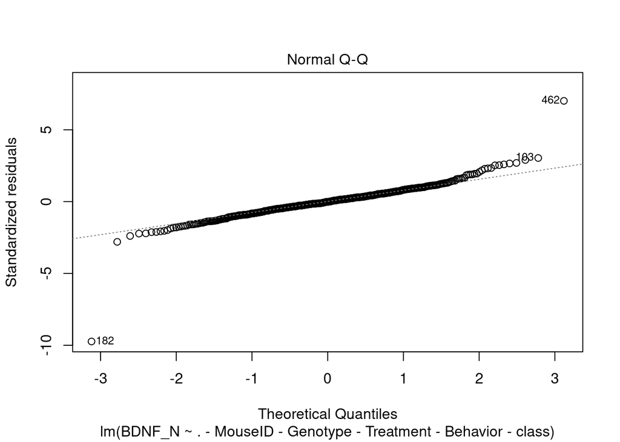

```r
plot(f_model, 2)
```

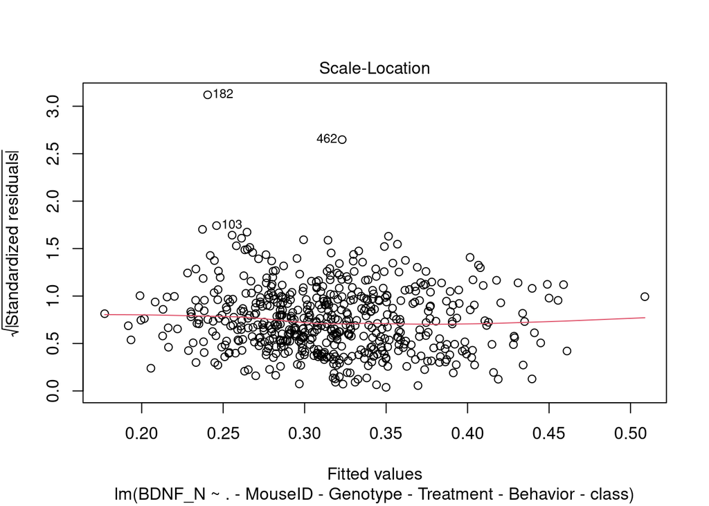

```r
plot(f_model, 3)
```

Cook’s distance also plots some outliers

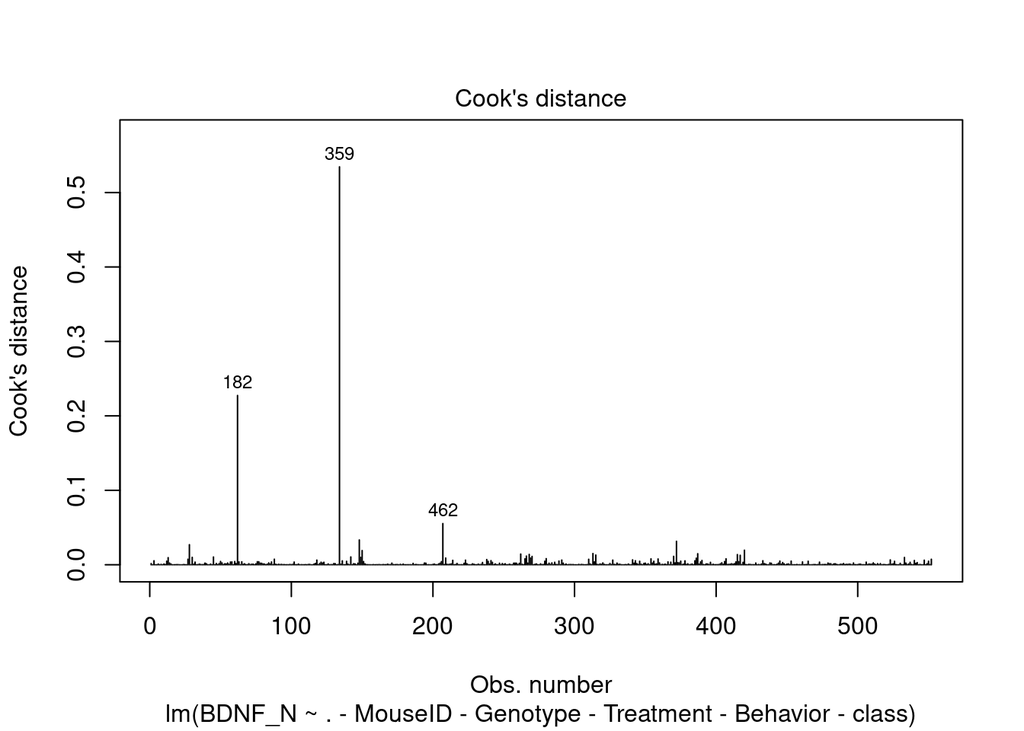

```r
plot(f_model, 4)
```

Multicollinearity within the data could be checked with correlation matrix, we could see that many pairs demonstrate high level of correlation (> 0.6)

```r
cor(complete_data[,2:78])
```

```
##                    DYRK1A_N      ITSN1_N      BDNF_N        NR1_N       NR2A_N
## DYRK1A_N         1.00000000  0.922361635  0.38278421  0.254820291  0.288368744
## ITSN1_N          0.92236164  1.000000000  0.53598062  0.430788523  0.428279149
## BDNF_N           0.38278421  0.535980618  1.00000000  0.832862228  0.747559392
## NR1_N            0.25482029  0.430788523  0.83286223  1.000000000  0.899796904
## NR2A_N           0.28836874  0.428279149  0.74755939  0.899796904  1.000000000
## pAKT_N          -0.12710431 -0.046645034  0.43750621  0.360170390  0.269293352
## pBRAF_N         -0.02665016  0.031511454  0.49988573  0.398750117  0.254086586
## pCAMKII_N       -0.07406235 -0.018897962  0.32714398  0.341446026  0.359483286
## pCREB_N          0.15641188  0.363706527  0.74858507  0.736001302  0.556803041
## pELK_N           0.51547277  0.516033150  0.41310177  0.411778883  0.379700025
## pERK_N           0.92440991  0.868392785  0.36942602  0.260754448  0.292738124
## pJNK_N          -0.05094447  0.092410233  0.58069095  0.596504993  0.514287414
## PKCA_N           0.33519586  0.443251337  0.76605397  0.620292036  0.545392507
## pMEK_N          -0.04092972  0.090705355  0.61462429  0.542057774  0.441471952
## pNR1_N           0.18212435  0.335227376  0.75519975  0.948532125  0.892327172
## pNR2A_N         -0.19835330 -0.071255358  0.41179642  0.611030901  0.570906798
## pNR2B_N          0.17498515  0.339310809  0.73385531  0.938288977  0.888735493
## pPKCAB_N         0.41831660  0.487068069  0.55209652  0.398856534  0.357770508
## pRSK_N           0.15101402  0.209734710  0.41680385  0.285584845  0.187899436
## AKT_N            0.00871931  0.180683173  0.62190670  0.727350448  0.683177603
## BRAF_N           0.91813060  0.848885685  0.36354042  0.208185034  0.212826945
## CAMKII_N         0.01243302  0.129301127  0.64413032  0.617796849  0.500823823
## CREB_N           0.05253206  0.124382376  0.53480413  0.361971950  0.243496288
## ELK_N            0.29864457  0.507412425  0.74241105  0.823789864  0.753700175
## ERK_N            0.34020524  0.546146731  0.79388685  0.853640037  0.847777492
## GSK3B_N          0.71695434  0.810457181  0.72521252  0.663988589  0.665486592
## JNK_N            0.24044064  0.351483084  0.75945157  0.667133525  0.542415264
## MEK_N            0.19481368  0.382162125  0.81346633  0.747026895  0.631248070
## TRKA_N           0.32693039  0.527308913  0.87079266  0.891089011  0.790894364
## RSK_N            0.01090946  0.093934380  0.55242594  0.441155061  0.253504125
## APP_N            0.57803911  0.721272536  0.71997204  0.543910375  0.501388951
## Bcatenin_N       0.24761531  0.441813484  0.78815811  0.928737818  0.877784365
## SOD1_N          -0.49950147 -0.390787891  0.05269294  0.177175137  0.083557556
## MTOR_N          -0.12518467 -0.113703101  0.43284517  0.401683552  0.360695858
## P38_N           -0.36100723 -0.399538506  0.04194036  0.039450181 -0.003750792
## pMTOR_N         -0.10240441 -0.039811440  0.43948050  0.537291887  0.532168451
## DSCR1_N          0.08062678  0.110919118  0.42245477  0.333143975  0.340425948
## AMPKA_N          0.17325003  0.270216580  0.71375220  0.714437474  0.741625997
## NR2B_N          -0.05874593  0.003153018  0.54188199  0.560966708  0.535173112
```

[output cut: 1349 more lines]

```
## pCASP9_N         0.196007919
## PSD95_N          0.087784219
## SNCA_N          -0.593095684
## Ubiquitin_N     -0.278086456
## pGSK3B_Tyr216_N  0.544473598
## SHH_N           -0.274716092
## BAD_N           -0.186303537
## BCL2_N          -0.325668964
## pS6_N           -0.374123955
## pCFOS_N         -0.361120104
## SYP_N            0.391148666
## H3AcK18_N       -0.149353501
## EGR1_N          -0.508548010
## H3MeK4_N        -0.265352409
## CaNA_N           1.000000000
```

We could conclude, that build linear model lacks basic support, and could not be used for prediction.